# COVID-19 Survey Analysis (Part 2: Data Extraction & Preprocessing)

### 4.2.3 Imputing missing data

Imputation replaces missing data with substituted values. A common approach is “imputation to the mean”, where missing values are replaced with the mean value of the respective variable. However, this approach artificially reduces the variance of the dataset and does not take into account additional information from other variables.

“Multiple Imputation by Chained Expressions” (MICE) is a more sophisticated approach for imputing missing data. If the pattern of missing data is random, then the statistical distribution of (unobserved) missing values should be no different from the (observed) existing data. As such, we can impute the missing data by resampling values from the existing data. We can also improve the quality imputation by using the observed data to predict likely values for the missing data.

In the previous section, we classified all variables listed in `datadict_exclNA` according to type, with `vars_cat`, `vars_con`, and `vars_ord` respectively containing all categorical, continuous, and ordinal variables that *did not require any preprocessing*. Variables that encoded any type of nonresponse were identified for preprocessing. Then, we recoded meaningful nonresponses as explicit values (e.g., `NA`s in `S7C` converted to `0`s) and random/nonsensical nonresponses as `NA`s. After recoding, variables that contained no `NA` values were appended to their respective `vars_{type}` list. Since imputation methods depend on data type, variables with `NA` values were saved into `vars_catbin_NA` (for binary categorical variables), `vars_catnom_NA` (for categorical variables with > 2 groups), `vars_con_NA`, and `vars_ord_NA`.

In the next code chunk, we will combine the `vars_{type}` objects into `data_preimpute`. Then, we will append `vars_{type}_NA` to `data_preimpute` to make `data_preimpute_{type}_NA`. This object is passed to `mice()`, which performs multiple imputation to replace any `NA`s with sensible values. The output is saved to `data_impute_{type}_NA`, and the imputed values from each object are recombined into a final complete dataset named `coviddata_imp`. Finally, we’ll clean up the environment and remove all R objects that will no longer be used.

**Please note that imputation is computationally intensive and can take several hours to complete. For the purposes of this report, the `data_impute_{type}_NA` objects were previously computed and are loaded into R from .RDS files.**

```r
# For each of the vars_X_NA, we need to impute the NA values. We can use the
# mice package to do this!

haven_binarize_yesno <- function(x) {
  a <- as_factor(x) %>% as.character()
  a[which(a == "No")] <- 0
  a[which(a == "Yes")] <- 1
  a <- as.numeric(a)
  return(a)
}

haven_ordered <- function(x) {
  a <- as_factor(x, ordered = TRUE, levels = "values")
  return(a)
}


# Prep datasets for each imputation

data_preimpute <- bind_cols(
  vars_cat %>% mutate(across(everything(), as_factor)),
  vars_ord %>% mutate(across(everything(), haven_ordered)),
  vars_con
)

data_preimpute_catbin_NA <- bind_cols(
  data_preimpute,
  vars_catbin_NA %>% mutate(across(everything(), as_factor))
) %>% zap_labels()

data_preimpute_catnom_NA <- bind_cols(
  data_preimpute,
  vars_catnom_NA %>% mutate(across(everything(), as_factor))
) %>% zap_labels()

data_preimpute_ord_NA <- bind_cols(
  data_preimpute,
  vars_ord_NA %>% mutate(across(everything(), haven_ordered))
  # vars_con_NA
) %>% zap_labels()

data_preimpute_con_NA <- bind_cols(
  data_preimpute,
  vars_con_NA
) %>% zap_labels()


# Check if data set has already been imputed and is unchanged; otherwise, redo

if (file.exists(paste0(getwd(), "/output/data_impute_catbin_NA.RDS"))) {
  data_check <- readRDS(file = paste0(getwd(), "/output/data_impute_catbin_NA.RDS"))
} else {
  data_check <- NULL
}

if (setequal(data_check$data, data_preimpute_catbin_NA)) {
  data_impute_catbin_NA <- data_check
} else {
  data_impute_catbin_NA <- mice(
    data = data_preimpute_catbin_NA,
    nnet.MaxNWts = 50000,
    seed = 1
  )
  saveRDS(object = data_impute_catbin_NA,
          file = paste0(getwd(), "/output/data_impute_catbin_NA.RDS"))
}

if (file.exists(paste0(getwd(), "/output/data_impute_catnom_NA.RDS"))) {
  data_check <- readRDS(file = paste0(getwd(), "/output/data_impute_catnom_NA.RDS"))
} else {
  data_check <- NULL
}

if (setequal(data_check$data, data_preimpute_catnom_NA)) {
  data_impute_catnom_NA <- data_check
} else {
  data_impute_catnom_NA <- mice(
    data = data_preimpute_catnom_NA,
    nnet.MaxNWts = 50000,
    seed = 1
  )

  saveRDS(object = data_impute_catnom_NA,
          file = paste0(getwd(), "/output/data_impute_catnom_NA.RDS"))
}

if (file.exists(paste0(getwd(), "/output/data_impute_ord_NA.RDS"))) {
  data_check <- readRDS(file = paste0(getwd(), "/output/data_impute_ord_NA.RDS"))
} else {
  data_check <- NULL
}

if (setequal(data_check$data, data_preimpute_ord_NA)) {
  data_impute_ord_NA <- data_check
} else {
  data_impute_ord_NA <- mice(
    data = data_preimpute_ord_NA,
    nnet.MaxNWts = 50000,
    seed = 1
  )

  saveRDS(object = data_impute_ord_NA,
          file = paste0(getwd(), "/output/data_impute_ord_NA.RDS"))
}

if (file.exists(paste0(getwd(), "/output/data_impute_con_NA.RDS"))) {
  data_check <- readRDS(file = paste0(getwd(), "/output/data_impute_con_NA.RDS"))
} else {
  data_check <- NULL
}

if (setequal(data_check$data, data_preimpute_con_NA)) {
  data_impute_con_NA <- data_check
} else {
  data_impute_con_NA <- mice(
    data = data_preimpute_con_NA,
    nnet.MaxNWts = 50000,
    seed = 1
  )

  saveRDS(object = data_impute_con_NA,
          file = paste0(getwd(), "/output/data_impute_con_NA.RDS"))
}

data_complete <- left_join(
  x = complete(data_impute_catbin_NA),
  y = complete(data_impute_catnom_NA),
  by = names(data_preimpute)
)

data_complete <- left_join(
  x = data_complete,
  y = complete(data_impute_ord_NA),
  by = names(data_preimpute)
)

data_complete <- left_join(
  x = data_complete,
  y = complete(data_impute_con_NA),
  by = names(data_preimpute)
)

detach(coviddata_exclNA)

# Save out objects required for analysis, then clean up the environment

coviddata_imp <- data_complete
datadict_imp <- datadict[names(data_complete)]
vars_imp <- list(
  cat = c(names(vars_cat),
          names(vars_catbin_NA),
          names(vars_catnom_NA)),
  con = c(names(vars_con),
          names(vars_con_NA)),
  ord = c(names(vars_ord),
          names(vars_ord_NA))
)

write_csv(data_complete, file = paste0(getwd(), "/output/data_imputed.csv"))

rm(
  C1B,
  C1C,
  C2,
  # coviddata,
  coviddata_exclNA,
  # coviddata_imp,
  coviddata_num,
  data_check,
  data_complete,
  data_impute_catbin_NA,
  data_impute_catnom_NA,
  data_impute_con_NA,
  data_impute_ord_NA,
  data_preimpute,
  data_preimpute_catbin_NA,
  data_preimpute_catnom_NA,
  data_preimpute_con_NA,
  data_preimpute_ord_NA,
  # datadict,
  datadict_exclNA,
  # datadict_imp,
  haven_binarize_yesno,
  haven_ordered,
  noanswerS16C_r1,
  noanswerS16C_r2,
  Q8AA,
  # required_packages,
  S11A,
  S11C,
  S15r99,
  S16B,
  S16Cr99,
  S17Ar99,
  S17Br99,
  S1B,
  S3,
  S4,
  S5,
  S6B,
  S6E,
  S6H,
  S7A,
  S7B,
  S7C,
  S8D,
  S8F,
  # using,
  vars_cat,
  vars_catbin_converttoNA,
  vars_catbin_NA,
  vars_catnom_convertto0,
  vars_catnom_convertto0andNA,
  vars_catnom_converttoNA,
  vars_catnom_NA,
  vars_con,
  vars_con_convertto0andNA,
  vars_con_NA,
  vars_dealwithlater,
  vars_excl,
  # vars_imp,
  vars_na1,
  vars_na2,
  vars_na3,
  vars_naall,
  vars_ord,
  vars_ord_converttoNA,
  vars_ord_NA
)
```

Before we move onto the next section, let’s take one last look at the missing data structure of `coviddata_imp`.

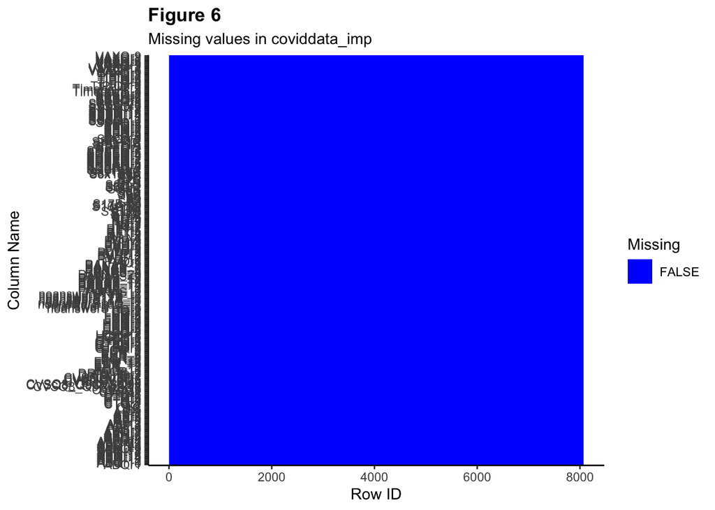

```r
coviddata_imp %>% plot_missing(data = ., title = "Figure 6", subtitle = "Missing values in coviddata_imp")
```

As we can see, there is no yellow in this chart! There are no missing values in the data. This complete data is now ready for outlier analysis and inferential statistics!

**Let’s move onto** *Part 3*.